# SE3. HW3. Suggested Solution

Author

Mykyta Horovoi

## 1. ADF Test (25% of the HW3 grade)

### a) Using a maximum of 12 lags, estimate models of the form $\Delta s_t = \alpha_0 + \gamma s_{t-1} + \Sigma\beta_i\Delta s_{t-i}$. Use the AIC, BIC, and general-to-specific (GTS) methods to select an appropriate lag length.

First, import `quarterly.xls` data set and create `spread` variable by subtracting `r5` from `Tbill`:

```r
df <- read_excel("quarterly.xls")
df <- df %>% mutate(DATE = yearquarter(DATE))
df_tsb <- df %>% as_tsibble(index = DATE)
df_model <- df_tsb %>% filter_index("1961 Q4" ~ "2012 Q4")
df_model <- df_model %>% mutate(spread = r5-Tbill)
df_model <- df_model %>%
  mutate(spread_diff = difference(spread))
```

Second, estimate 12 ADF models

```r
max_lag <- 12 # setup maximum number of lags
adf_list <- list() # empty list for models
aic_list <- list() # list for AIC values
bic_list <- list() # list for BIC values
for (i in 1:max_lag) {
  adf_list[[i]] <- ur.df2(df_model$spread, lags = i, type = "drift")
  aic_list[[i]] <- adf_list[[i]]$aic
  bic_list[[i]] <- adf_list[[i]]$bic
}
```

Select models with minimum AIC/BIC

```r
which.min(aic_list)
```

```
[1] 9
```

```r
which.min(bic_list)
```

```
[1] 3
```

Select a lag length using GTS method

```r
adf_list[[12]]$testreg # the last lag is insignificant at 5%
```

```
Call:
lm(formula = z.diff ~ z.lag.1 + 1 + z.diff.lag)

Residuals:
     Min       1Q   Median       3Q      Max
-2.31764 -0.25208 -0.06879  0.24679  1.61473

Coefficients:
              Estimate Std. Error t value Pr(>|t|)
(Intercept)   0.310826   0.081291   3.824 0.000182 ***
z.lag.1      -0.251345   0.060316  -4.167 4.81e-05 ***
z.diff.lag1   0.345412   0.081565   4.235 3.66e-05 ***
z.diff.lag2  -0.061587   0.081440  -0.756 0.450514
z.diff.lag3   0.293502   0.080691   3.637 0.000361 ***
z.diff.lag4  -0.009132   0.082811  -0.110 0.912312
z.diff.lag5   0.171796   0.082820   2.074 0.039487 *
z.diff.lag6  -0.041826   0.081788  -0.511 0.609702
z.diff.lag7  -0.008883   0.078865  -0.113 0.910445
z.diff.lag8   0.212967   0.078692   2.706 0.007465 **
z.diff.lag9   0.086328   0.077833   1.109 0.268868
z.diff.lag10  0.085149   0.078381   1.086 0.278795
z.diff.lag11 -0.103038   0.075298  -1.368 0.172909
z.diff.lag12  0.096368   0.075365   1.279 0.202673
---
Signif. codes:  0 '***' 0.001 '**' 0.01 '*' 0.05 '.' 0.1 ' ' 1

Residual standard error: 0.4774 on 178 degrees of freedom
Multiple R-squared:  0.2482,    Adjusted R-squared:  0.1933
F-statistic:  4.52 on 13 and 178 DF,  p-value: 1.195e-06
```

```r
adf_list[[11]]$testreg # the last lag is insignificant at 5%
```

```
Call:
lm(formula = z.diff ~ z.lag.1 + 1 + z.diff.lag)

Residuals:
     Min       1Q   Median       3Q      Max
-2.31164 -0.27081 -0.06383  0.25886  1.64284

Coefficients:
             Estimate Std. Error t value Pr(>|t|)
(Intercept)   0.28187    0.07852   3.590 0.000427 ***
z.lag.1      -0.22837    0.05782  -3.950 0.000112 ***
z.diff.lag1   0.31462    0.07797   4.035 8.05e-05 ***
z.diff.lag2  -0.07895    0.08041  -0.982 0.327545
z.diff.lag3   0.27993    0.08003   3.498 0.000590 ***
z.diff.lag4  -0.01319    0.08275  -0.159 0.873534
z.diff.lag5   0.14909    0.08073   1.847 0.066411 .
z.diff.lag6  -0.07154    0.07864  -0.910 0.364157
z.diff.lag7  -0.01658    0.07861  -0.211 0.833201
z.diff.lag8   0.18951    0.07651   2.477 0.014180 *
z.diff.lag9   0.09100    0.07773   1.171 0.243247
z.diff.lag10  0.05721    0.07512   0.762 0.447320
z.diff.lag11 -0.09408    0.07501  -1.254 0.211397
---
Signif. codes:  0 '***' 0.001 '**' 0.01 '*' 0.05 '.' 0.1 ' ' 1

Residual standard error: 0.4773 on 180 degrees of freedom
Multiple R-squared:  0.2403,    Adjusted R-squared:  0.1897
F-statistic: 4.745 on 12 and 180 DF,  p-value: 1.008e-06
```

```r
adf_list[[10]]$testreg # the last lag is insignificant at 5%
```

```
Call:
lm(formula = z.diff ~ z.lag.1 + 1 + z.diff.lag)

Residuals:
     Min       1Q   Median       3Q      Max
-2.30542 -0.26249 -0.07535  0.25503  1.67041

Coefficients:
              Estimate Std. Error t value Pr(>|t|)
(Intercept)   0.308492   0.075043   4.111 5.96e-05 ***
z.lag.1      -0.251197   0.054655  -4.596 8.03e-06 ***
z.diff.lag1   0.332766   0.076454   4.352 2.24e-05 ***
z.diff.lag2  -0.067157   0.079756  -0.842 0.400874
z.diff.lag3   0.286132   0.079805   3.585 0.000432 ***
z.diff.lag4   0.010276   0.080606   0.127 0.898697
z.diff.lag5   0.177842   0.077184   2.304 0.022344 *
z.diff.lag6  -0.064335   0.078361  -0.821 0.412718
z.diff.lag7   0.006493   0.076364   0.085 0.932329
z.diff.lag8   0.186206   0.076401   2.437 0.015763 *
z.diff.lag9   0.120130   0.074199   1.619 0.107176
z.diff.lag10  0.050711   0.074801   0.678 0.498665
---
Signif. codes:  0 '***' 0.001 '**' 0.01 '*' 0.05 '.' 0.1 ' ' 1

Residual standard error: 0.4769 on 182 degrees of freedom
Multiple R-squared:  0.2332,    Adjusted R-squared:  0.1869
F-statistic: 5.033 on 11 and 182 DF,  p-value: 7.712e-07
```

```r
adf_list[[9]]$testreg # the last lag is insignificant at 5%
```

```
Call:
lm(formula = z.diff ~ z.lag.1 + 1 + z.diff.lag)

Residuals:
     Min       1Q   Median       3Q      Max
-2.30508 -0.25723 -0.06833  0.26024  1.65979

Coefficients:
             Estimate Std. Error t value Pr(>|t|)
(Intercept)  0.293877   0.071510   4.110 5.96e-05 ***
z.lag.1     -0.239162   0.051479  -4.646 6.44e-06 ***
z.diff.lag1  0.327044   0.075668   4.322 2.53e-05 ***
z.diff.lag2 -0.070584   0.079261  -0.891  0.37435
z.diff.lag3  0.274570   0.077604   3.538  0.00051 ***
z.diff.lag4 -0.005551   0.076837  -0.072  0.94248
z.diff.lag5  0.174611   0.076713   2.276  0.02399 *
z.diff.lag6 -0.076912   0.075814  -1.014  0.31168
z.diff.lag7  0.008177   0.076004   0.108  0.91444
z.diff.lag8  0.171221   0.072797   2.352  0.01973 *
z.diff.lag9  0.124590   0.073577   1.693  0.09208 .
---
Signif. codes:  0 '***' 0.001 '**' 0.01 '*' 0.05 '.' 0.1 ' ' 1

Residual standard error: 0.4749 on 184 degrees of freedom
Multiple R-squared:  0.2313,    Adjusted R-squared:  0.1895
F-statistic: 5.537 on 10 and 184 DF,  p-value: 3.399e-07
```

```r
adf_list[[8]]$testreg # the last lag is significant at 5%
```

```
Call:
lm(formula = z.diff ~ z.lag.1 + 1 + z.diff.lag)

Residuals:
     Min       1Q   Median       3Q      Max
-2.34247 -0.24862 -0.05621  0.23991  1.66663

Coefficients:
            Estimate Std. Error t value Pr(>|t|)
(Intercept)  0.26132    0.06900   3.787 0.000205 ***
z.lag.1     -0.21272    0.04918  -4.325 2.49e-05 ***
z.diff.lag1  0.32369    0.07582   4.269 3.12e-05 ***
z.diff.lag2 -0.10034    0.07743  -1.296 0.196632
z.diff.lag3  0.23949    0.07498   3.194 0.001648 **
z.diff.lag4 -0.01346    0.07688  -0.175 0.861200
z.diff.lag5  0.14669    0.07510   1.953 0.052279 .
z.diff.lag6 -0.07361    0.07597  -0.969 0.333830
z.diff.lag7 -0.02993    0.07273  -0.412 0.681136
z.diff.lag8  0.18537    0.07247   2.558 0.011331 *
---
Signif. codes:  0 '***' 0.001 '**' 0.01 '*' 0.05 '.' 0.1 ' ' 1

Residual standard error: 0.476 on 186 degrees of freedom
Multiple R-squared:  0.2193,    Adjusted R-squared:  0.1815
F-statistic: 5.805 on 9 and 186 DF,  p-value: 4.119e-07
```

Summarize the results:

| Criterion | Optimal lag length |
| --- | --- |
| AIC | 9 |
| BIC | 3 |
| GTS | 8 |

### b) Using a lag length 8 and perform an aumented Dickey-Fuller test of `spread`. You shoud find

$$\Delta s_t = 0.255 -0.211s_{t-1} + \Sigma\beta_i\Delta s_{t-i}$$

### Is the spread stationary?

Display estimated model with 8 lags:

```r
adf_list[[8]]$testreg
```

```
Call:
lm(formula = z.diff ~ z.lag.1 + 1 + z.diff.lag)

Residuals:
     Min       1Q   Median       3Q      Max
-2.34247 -0.24862 -0.05621  0.23991  1.66663

Coefficients:
            Estimate Std. Error t value Pr(>|t|)
(Intercept)  0.26132    0.06900   3.787 0.000205 ***
z.lag.1     -0.21272    0.04918  -4.325 2.49e-05 ***
z.diff.lag1  0.32369    0.07582   4.269 3.12e-05 ***
z.diff.lag2 -0.10034    0.07743  -1.296 0.196632
z.diff.lag3  0.23949    0.07498   3.194 0.001648 **
z.diff.lag4 -0.01346    0.07688  -0.175 0.861200
z.diff.lag5  0.14669    0.07510   1.953 0.052279 .
z.diff.lag6 -0.07361    0.07597  -0.969 0.333830
z.diff.lag7 -0.02993    0.07273  -0.412 0.681136
z.diff.lag8  0.18537    0.07247   2.558 0.011331 *
---
Signif. codes:  0 '***' 0.001 '**' 0.01 '*' 0.05 '.' 0.1 ' ' 1

Residual standard error: 0.476 on 186 degrees of freedom
Multiple R-squared:  0.2193,    Adjusted R-squared:  0.1815
F-statistic: 5.805 on 9 and 186 DF,  p-value: 4.119e-07
```

Display test statistics

```r
adf_list[[8]]
```

```
=== Test statistics =========
               tau2     phi1
statistic -4.324936 9.353723

=== Test critical values ====
      1pct  5pct 10pct
tau2 -3.46 -2.88 -2.57
phi1  6.52  4.63  3.81

=== Combined output =========
[1] "-4.32 [8]***"
```

Tau test statistics < Tau critical values -> The spread is stationary.

### c) Perform an augmented Dickey-Fuller test of the 5-year rate using seven lags. Is the 5-year rate stationary?

```r
r5_adf <- ur.df2(df_model$r5, lags = 7, type = "drift")
r5_adf$testreg # estimated model
```

```
Call:
lm(formula = z.diff ~ z.lag.1 + 1 + z.diff.lag)

Residuals:
     Min       1Q   Median       3Q      Max
-2.20559 -0.31573  0.01676  0.31372  1.59215

Coefficients:
             Estimate Std. Error t value Pr(>|t|)
(Intercept)  0.057966   0.103808   0.558  0.57724
z.lag.1     -0.011290   0.014769  -0.764  0.44560
z.diff.lag1  0.297575   0.072145   4.125 5.57e-05 ***
z.diff.lag2 -0.225483   0.075324  -2.993  0.00313 **
z.diff.lag3  0.204865   0.076417   2.681  0.00800 **
z.diff.lag4 -0.006998   0.077814  -0.090  0.92844
z.diff.lag5 -0.114414   0.076652  -1.493  0.13721
z.diff.lag6  0.040032   0.075082   0.533  0.59454
z.diff.lag7 -0.174916   0.072453  -2.414  0.01673 *
---
Signif. codes:  0 '***' 0.001 '**' 0.01 '*' 0.05 '.' 0.1 ' ' 1

Residual standard error: 0.5533 on 188 degrees of freedom
Multiple R-squared:  0.1561,    Adjusted R-squared:  0.1202
F-statistic: 4.348 on 8 and 188 DF,  p-value: 7.85e-05
```

```r
r5_adf # test statistics
```

```
=== Test statistics =========
               tau2      phi1
statistic -0.764384 0.3684556

=== Test critical values ====
      1pct  5pct 10pct
tau2 -3.46 -2.88 -2.57
phi1  6.52  4.63  3.81

=== Combined output =========
[1] "-0.76 [7] "
```

Tau test statistics > Tau critical values -> The 5-year rate is non-stationary.

### d) Perform an augmented Dickey-Fuller test of the t-bill rate using 11 lags. Is the t-bill rate stationary?

```r
tbill_adf <- ur.df2(df_model$Tbill, lags = 11, type = "drift")
tbill_adf$testreg # estimated model
```

```
Call:
lm(formula = z.diff ~ z.lag.1 + 1 + z.diff.lag)

Residuals:
    Min      1Q  Median      3Q     Max
-3.2881 -0.2396  0.0441  0.3242  3.1688

Coefficients:
             Estimate Std. Error t value Pr(>|t|)
(Intercept)   0.11560    0.11281   1.025  0.30687
z.lag.1      -0.02456    0.01907  -1.288  0.19949
z.diff.lag1   0.42488    0.07363   5.770 3.40e-08 ***
z.diff.lag2  -0.38098    0.08007  -4.758 4.00e-06 ***
z.diff.lag3   0.42635    0.08426   5.060 1.03e-06 ***
z.diff.lag4  -0.17339    0.08957  -1.936  0.05447 .
z.diff.lag5   0.16356    0.08719   1.876  0.06228 .
z.diff.lag6  -0.00627    0.08800  -0.071  0.94328
z.diff.lag7  -0.27956    0.08742  -3.198  0.00164 **
z.diff.lag8   0.16939    0.08852   1.914  0.05726 .
z.diff.lag9  -0.10422    0.08462  -1.232  0.21973
z.diff.lag10  0.09896    0.07912   1.251  0.21268
z.diff.lag11 -0.16231    0.07404  -2.192  0.02966 *
---
Signif. codes:  0 '***' 0.001 '**' 0.01 '*' 0.05 '.' 0.1 ' ' 1

Residual standard error: 0.6642 on 180 degrees of freedom
Multiple R-squared:  0.3195,    Adjusted R-squared:  0.2742
F-statistic: 7.043 on 12 and 180 DF,  p-value: 1.957e-10
```

```r
tbill_adf # test statistics
```

```
=== Test statistics =========
               tau2      phi1
statistic -1.287743 0.8844327

=== Test critical values ====
      1pct  5pct 10pct
tau2 -3.46 -2.88 -2.57
phi1  6.52  4.63  3.81

=== Combined output =========
[1] "-1.29 [11] "
```

Tau test statistics > Tau critical values -> The t-bill rate is non-stationary.

### e) How is it possible that the individual rates act as I(1) processes whereas the spread acts as a stitionary process?

The individual rates are cointegrated -> linear combination of I(1) processes is an I(0) process.

## 2. Forecast Evaluation (25% of the HW3 grade)

Create train and test sets

```r
df_train <- df_model[1:(nrow(df_model)-50),]
df_test <- df_model[(nrow(df_model)-49):nrow(df_model),]
h_len <- nrow(df_test) # size of a holdback period
```

#### Estimate AR(7) and ARMA[2,(1,7)] models on a train data

```r
# estimate models and generate one-step-ahead forecast
pred_ar7 <- numeric(h_len)
pred_ar217 <- numeric(h_len)

for (i in 1:h_len){
  ar7 <- arima(df_model$spread[1:(155+i-1)], order = c(7,0,0))
  arma217 <- arima(df_model$spread[1:(155+i-1)], order = c(2, 0, 7),
                      fixed = c(NA,NA, NA,0,0,0,0,0, NA, NA))

  pred_ar7[i] <- predict(ar7, n.ahead = 1)$pred
  pred_ar217[i] <- predict(arma217, n.ahead = 1)$pred
}
```

Let $e_{1t}$ denote the forecast errors from the AR(7) model and $e_{2t}$ denote the forecast errors from the ARMA[2,(1,7)] model

```r
# create error terms
e1 <- df_test$spread - pred_ar7
e2 <-  df_test$spread - pred_ar217
```

| Term | Mean | Variance |
| --- | --- | --- |
| $e_{1t}$ | 0.0121348 | 0.1854272 |
| $e_{2t}$ | 0.0111857 | 0.1685739 |

#### Estimate MSPE, Bias, RMSE, MAE, MAPE

```r
# MSPE
mspe_ar7 <- round(sum(e1^2)/h_len, 4)
mspe_ar217 <- round(sum(e2^2)/h_len, 4)

# Bias
bias_ar7 <- round(sum(e1)/50, 4)
bias_ar217 <- round(sum(e2)/50, 4)

# MRSE
mrse_ar7 <- round(sqrt(sum(e1^2)/h_len), 4)
mrse_ar217 <- round(sqrt(sum(e2^2)/h_len), 4)

# MAE
mae_ar7 <- round(sum(abs(e1))/h_len, 4)
mae_ar217 <- round(sum(abs(e2))/h_len, 4)

# MAPE
mape_ar7 <- round(sum(abs(e1/df_test$spread))/h_len, 4)
mape_ar217 <- round(sum(abs(e2/df_test$spread))/h_len, 4)
```

**Summary table of point forecast accuracy metrics**

| Parameter | AR(7) | ARMA[2,(1,7)] |
| --- | --- | --- |
| Bias | 0.0121 | 0.0112 |
| MSPE | 0.1819 | 0.1653 |
| MRSE | 0.4265 | 0.4066 |
| MAE | 0.3286 | 0.3162 |
| MAPE | 1.3592 | 1.3033 |

#### Test the significance of bias

```r
# estimate models
pred_mod1 <- lm(df_test$spread ~ pred_ar7) # AR(7) bias
pred_mod2 <- lm(df_test$spread ~ pred_ar217) # ARMA[2,(1,7)] bias

# calculate F-statistics for H0: intercept = 0, slope = 1
linearHypothesis(pred_mod1, c("(Intercept) = 0", "pred_ar7 = 1")) # can't reject H0
```

```
Linear hypothesis test

Hypothesis:
(Intercept) = 0
pred_ar7 = 1

Model 1: restricted model
Model 2: df_test$spread ~ pred_ar7

  Res.Df    RSS Df Sum of Sq      F Pr(>F)
1     50 9.0933
2     48 9.0647  2  0.028577 0.0757 0.9272
```

```r
linearHypothesis(pred_mod2, c("(Intercept) = 0", "pred_ar217 = 1")) # can't reject H0
```

```
Linear hypothesis test

Hypothesis:
(Intercept) = 0
pred_ar217 = 1

Model 1: restricted model
Model 2: df_test$spread ~ pred_ar217

  Res.Df    RSS Df Sum of Sq      F Pr(>F)
1     50 8.2664
2     48 8.2584  2  0.008009 0.0233  0.977
```

Regressions of the holdback data on forecasted values:

$$AR(7): \ s_t = 0.0447 + 0.974f_{1t},
\\ F-statistics: \ 0.0757$$

$$ARMA[2,(1,7)]: \ s_t = 0.0016 + 1.008f_{2t},
\\ F-statistics: \ 0.0233$$

Both predictions are unbiased.

#### Conduct the Granger-Newbold Test

```r
x <- e1 + e2
z <- e1 - e2
# calculate a correlation between z and x
r_zx <- cor(z,x)

# calculate Granger-Newbold statistics
gn_stat <- r_zx/(sqrt((1-r_zx^2)/(length(e1)-1)))
```

Correlation between $z_i = e_{1t} - e_{2t}$ and $x_i = e_{1t} + e_{2t}$ is $r_{zx}$ = 0.231.  
Granger-Newbold statistics is 1.67 that is not statistically significant at $df = 49$.

## 3. GARCH (50% of the HW3 grade)

#### Estimate ARMA[2,(1,7)] model on a full data set

```r
# prepare data set
df_full <- df_tsb %>% filter_index("1960 Q3" ~ "2012 Q4")
df_full <- df_full %>% mutate(spread = r5-Tbill)
df_full <- df_full %>%
  mutate(spread_diff = difference(spread))

# estimate model
arma217 <- arima(df_full$spread, order = c(2, 0, 7), fixed = c(NA,NA, NA, 0,0,0,0,0, NA, NA))

# Estimate the McLeod–Li test using a lag length of seven quarters
df_full$resid2 <- arma217$residuals^2

# regress squared residuals on it's 7th lag
model_mll <- dynlm(resid2 ~ L(resid2, 1:7), data = df_full)
```

Equation for the McLeod–Li test using a lag length of seven quarters:

$$\hat{\varepsilon}^2_{t} = 0.075 - 0.021\hat{\varepsilon}^2_{t-1} + 0.13\hat{\varepsilon}^2_{t-2} + 0.09\hat{\varepsilon}^2_{t-3} + 0.256\hat{\varepsilon}^2_{t-4} - 0.027\hat{\varepsilon}^2_{t-5} - 0.091\hat{\varepsilon}^2_{t-6} + 0.304\hat{\varepsilon}^2_{t-7}$$

Conduct LM-Test for an ARCH effect

```r
# create a function to calculate TR^2 and chi-squared at given level
arch_test <- function(model, signif_list, data) {
  len <- nrow(data)
  len_chi <- length(signif_list)
  q <- length(coef(model)) - 1
  r2 <- summary(model)$r.squared
  TR2 <- (len-q)*r2

  chi_list <- numeric(len_chi)
  for (i in 1:len_chi) {
    chi_list[i] <- qchisq(1 - signif_list[i], q)
  }
  result <- as.data.frame(c(TR2, chi_list))
  rownames(result) <- c('TR^2', paste0('Chi-squared at ', signif_list*100, '%'))
  colnames(result) <- c('Values')
  result
}

# calculate statistics for residuals of ARMA[2,(1,7)] model
kable(arch_test(model_mll, c(0.05, 0.01), df_full))
```

|  | Values |
| --- | --- |
| TR^2 | 47.22427 |
| Chi-squared at 5% | 14.06714 |
| Chi-squared at 1% | 18.47531 |

#### Estimate GARCH(1,1) model

```r
# model on data
garch11_spec <- ugarchspec(
  variance.model = list(model = "sGARCH", garchOrder = c(1,1)),
  mean.model = list(armaOrder = c(2,7)),
  fixed.pars = list(ma2 = 0, ma3 = 0, ma4 = 0, ma5 = 0, ma6 = 0)
)

garch11_fit <- ugarchfit(spec = garch11_spec, data = df_full$spread, solver = "gosolnp")
```

Depict an estimated model (note the R doesn’t estimate a real intercept for the mean model):

$$s_{t} = 1.165 + 0.453s_{t-1} + 0.356s_{t-2} + \varepsilon_{t} + 0.725\varepsilon_{t-1} -0.129\varepsilon_{t-7}$$

$$h_{t} = 0.0116 + 0.193\varepsilon_{t-1}^2 + 0.766h_{t-1}$$

Check autocorrelations for standartized residuals:

```r
# create a function to build acf on standartized residuals
acf_garch <- function(model, max_lag, squared) {
  ifelse(squared == TRUE, assign('resid', model@fit$z^2), assign('resid', model@fit$z))
  acf <- acf(resid, plot = FALSE, lag.max = max_lag)
  acf[1:max_lag]
}

# acf for the standartized residuals
acf_garch(garch11_fit, 8, FALSE)
```

```
Autocorrelations of series 'resid', by lag

     1      2      3      4      5      6      7      8
 0.066  0.013  0.016  0.071 -0.066 -0.131 -0.014  0.053
```

```r
# acf for the squared standartized residuals
acf_garch(garch11_fit, 8, TRUE)
```

```
Autocorrelations of series 'resid', by lag

     1      2      3      4      5      6      7      8
-0.118  0.184  0.001  0.059  0.013 -0.052  0.154 -0.034
```

The McLeod-Li test

```r
resid2 <- garch11_fit@fit$z^2
# regress squared standartized residuals on it's 2nd lag
model_mll <- lm(resid2 ~ lag(resid2, 1) + lag(resid2, 2))
```

$$\hat{\varepsilon}^2_{t}/h_{t} = 0.89 - 0.10\hat{\varepsilon}^2_{t-1}/h_{t-1} + 0.17\hat{\varepsilon}^2_{t-2}/h_{t-2}$$

LM-Test for an ARCH effect

```r
# calculate statistics for residuals of GARCH(1,1) model
kable(arch_test(model_mll, c(0.05, 0.02), df_full))
```

|  | Values |
| --- | --- |
| TR^2 | 9.059818 |
| Chi-squared at 5% | 5.991465 |
| Chi-squared at 2% | 7.824046 |

#### Estimate ARCH(2) model

```r
# model on data
arch2_spec <- ugarchspec(
  variance.model = list(model = "sGARCH", garchOrder = c(2,0)),
  mean.model = list(armaOrder = c(2,7)),
  fixed.pars = list(ma2 = 0, ma3 = 0, ma4 = 0, ma5 = 0, ma6 = 0)
)

arch2_fit <- ugarchfit(spec = arch2_spec, data = df_full$spread, solver = "gosolnp")
```

State an estimated model (note the R doesn’t estimate a real intercept for the mean model):

$$s_{t} = 1.207 + 0.576s_{t-1} + 0.161s_{t-2} + \varepsilon_{t} + 0.689\varepsilon_{t-1} -0.114\varepsilon_{t-7}$$

$$h_{t} = 0.119 + 0.066\varepsilon_{t-1}^2 + 0.401\varepsilon_{t-2}^2$$

Check autocorrelations for standartized residuals:

```r
# acf for the standartized residuals
acf_garch(arch2_fit, 8, FALSE)
```

```
Autocorrelations of series 'resid', by lag

     1      2      3      4      5      6      7      8
-0.043  0.093  0.080  0.076 -0.017 -0.091 -0.017  0.043
```

```r
# acf for the squared standartized residuals
acf_garch(arch2_fit, 8, TRUE)
```

```
Autocorrelations of series 'resid', by lag

     1      2      3      4      5      6      7      8
-0.011 -0.041  0.210  0.216  0.010 -0.015  0.245  0.081
```

The McLeod-Li test

```r
resid2 <- arch2_fit@fit$z^2
# regress squared standartized residuals on it's 2nd lag
model_mll <- lm(resid2 ~ lag(resid2, 1) + lag(resid2, 2) + lag(resid2, 3) + lag(resid2, 4))
```

$$\hat{\varepsilon}^2_{t}/h_{t} = 0.64 - 0.054\hat{\varepsilon}^2_{t-1}/h_{t-1} - 0.03\hat{\varepsilon}^2_{t-2}/h_{t-2} + 0.21\hat{\varepsilon}^2_{t-3}/h_{t-3} + 0.23\hat{\varepsilon}^2_{t-4}/h_{t-4}$$

LM-Test for an ARCH effect

```r
# calculate statistics for residuals of GARCH(1,1) model
kable(arch_test(model_mll, c(0.05, 0.01), df_full))
```

|  | Values |
| --- | --- |
| TR^2 | 19.748760 |
| Chi-squared at 5% | 9.487729 |
| Chi-squared at 1% | 13.276704 |

#### Estimate ARCH(3) model

```r
# model on data
arch3_spec <- ugarchspec(
  variance.model = list(model = "sGARCH", garchOrder = c(3,0)),
  mean.model = list(armaOrder = c(2,7)),
  fixed.pars = list(ma2 = 0, ma3 = 0, ma4 = 0, ma5 = 0, ma6 = 0)
)

arch3_fit <- ugarchfit(spec = arch3_spec, data = df_full$spread, solver = "gosolnp")
```

State an estimated model (note the R doesn’t estimate a real intercept for the mean model):

$$s_{t} = 1.09 + 0.559s_{t-1} + 0.223s_{t-2} + \varepsilon_{t} + 0.715\varepsilon_{t-1} -0.158\varepsilon_{t-7}$$

$$h_{t} = 0.069 + 0.066\varepsilon_{t-1}^2 + 0.381\varepsilon_{t-2}^2 + 0.289\varepsilon_{t-3}^2$$

Check autocorrelations for standartized residuals:

```r
# acf for the standartized residuals
acf_garch(arch3_fit, 8, FALSE)
```

```
Autocorrelations of series 'resid', by lag

     1      2      3      4      5      6      7      8
-0.034  0.073  0.043  0.072 -0.050 -0.111  0.039 -0.015
```

```r
# acf for the squared standartized residuals
acf_garch(arch3_fit, 8, TRUE)
```

```
Autocorrelations of series 'resid', by lag

     1      2      3      4      5      6      7      8
-0.065 -0.032 -0.052  0.156 -0.041 -0.029  0.149  0.025
```

The McLeod-Li test

```r
resid2 <- arch3_fit@fit$z^2
# regress squared standartized residuals on it's 2nd lag
model_mll <- lm(resid2 ~ lag(resid2, 1) + lag(resid2, 2) + lag(resid2, 3) + lag(resid2, 4))
```

$$\hat{\varepsilon}^2_{t}/h_{t} = 0.99 - 0.064\hat{\varepsilon}^2_{t-1}/h_{t-1} - 0.036\hat{\varepsilon}^2_{t-2}/h_{t-2} - 0.048\hat{\varepsilon}^2_{t-3}/h_{t-3} + 0.149\hat{\varepsilon}^2_{t-4}/h_{t-4}$$

LM-Test for an ARCH effect

```r
# calculate statistics for residuals of GARCH(1,1) model
kable(arch_test(model_mll, c(0.05, 0.01), df_full))
```

|  | Values |
| --- | --- |
| TR^2 | 6.494996 |
| Chi-squared at 5% | 9.487729 |
| Chi-squared at 1% | 13.276704 |

**Compare all models using AIC and BIC (values are extracted from summary tables)**

| Model | AIC | BIC |
| --- | --- | --- |
| GARCH(1,1) | 1.1622 | 1.2897 |
| ARCH(2) | 1.2249 | 1.3524 |
| ARCH(3) | 1.1635 | 1.3070 |

#### Plot In-Sample Forecast of the Spread using ARCH(3) model

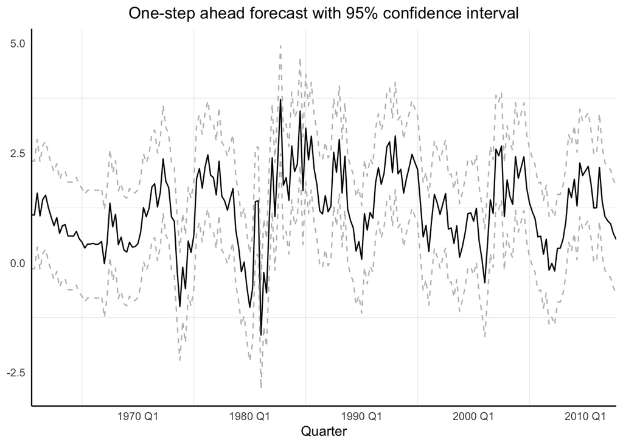

```r
# extract forecasted (fitted) values and boundaries
df_full$fit <- arch3_fit@fit$fitted.values
df_full$high <- df_full$fit + sqrt(var(df_full$fit) * 1.96)
df_full$low <- df_full$fit - sqrt(var(df_full$fit) * 1.96)

df_full %>% ggplot(aes(y = fit, x = DATE)) +
  geom_line() +
  geom_line(aes(y = high, x = DATE), color = "grey", linetype = "dashed") +
  geom_line(aes(y = low, x = DATE), color = "grey", linetype = "dashed") +
  theme_minimal() +
  labs(title = "One-step ahead forecast with 95% confidence interval",
       x = "Quarter",
       y = NULL) +
  theme(panel.grid.major = element_blank(),
        axis.line = element_line(colour = "black"),
        plot.title = element_text(hjust = 0.5)) +
  scale_x_yearquarter(expand = c(0, 0))
```

**End of the suggested solution.**